# Re_analysis_NOAA9

Brian

2024-04-28

# Revisit objectives

Has the ITV changed at high elevation across two study watersheds in Colorado, and if so, how? 1) Determine the temperature bias correction for individual SNOTEL stations within the study sites. 2) Compute ITV after removing seasonal and long-term climate change-induced trends. 3) Examine the elevational, seasonal, and spatial distribution of ITV across the two study watersheds.

There are three bias correction methods to address the first objective: the National Oceanic and Atmospheric Administration (NOAA) 9th order polynomial correction (or “NOAA9”) recommended by the Snow Survey (Atwood et al., 2023), the 4th order polynomial correction based on the co-located new and old sensor sites in Idaho (referred to as the “Morrisey” method) (Ma et al., 2019), and the Oyler et al., (2015) dataset.

Start new document

## 1) NOAA9 -> NOAA4?

NOAA6 is better and not as unrealistically complicated as NOAA9

## 2) COOP Stations GHCN

1. Trend differences? Statistically different? Among the GHCN and adjacent non-GHCN station
2. Examine station metadata – how often and much (?) did they move
3. “write everything down, these are our options, what we want to do, what we don’t”

## 3) Seasons at SNOTEL

1. Accumulation (start of accumulation to peak), melt (peak to SAG), snow free (SAG to start of accumulation)
2. Fix the period, or average start of accumulation/melt/SAG?
3. Are these the same dates for all stations, or the same for each station

## 4) ITV removing the annual average vs removing annual seasonal average?

## 5) Analysis using Tmax/Tmin?

1. In theory this should be easy if the code is set up?

Yes, the only reason we didn’t originally try it was due to many SNOTEL minimums being -51°C, which was erroneous.

## 6) Interpolation?

“Is it better than what Oyler did? Low elevation stations don’t represent higher elevation stations.” Need to discuss what we don’t do.

We need to at least discuss this.

## 7) Compare climate normal ITV against only post-sensor change ITV for SNOTEL

As Tmax, Tmin, with code in hand, this should be easy

## 8) Download Oyler data for Crosho & Ripple Creek

Working again with Crosho:

### Crosho SNOTEL

```
SNOTEL_426 <- snotel_download(site_id = 426, path = tempdir('../data'), internal = TRUE)
write.csv(SNOTEL_426,"C:/Users/steen/OneDrive/Documents/R/Projects/zombie_code/data_raw/snotel_426.csv", row.names = FALSE) #write in the raw data
```

```r
snotel_4_2_6 <- read.csv("C:/Users/steen/OneDrive/Documents/R/Projects/zombie_code/data_raw/snotel_426.csv", header = TRUE)
```

### Crosho 4_2_6

YSI sensor change date 7/21/2005

```r
#str(snotel_4_2_6) # check the date, usually a character.

snotel_4_2_6$Date <- as.Date(snotel_4_2_6$date) #change date from character to date format, capitalize to work with Water year functon from NWIS.

#THIS WILL CHANGE FOR EACH STATION
snotel_4_2_6_clean <- snotel_4_2_6 %>% # filter for the timeframe
  filter(Date >= "2005-07-21" & Date <= "2023-09-30") %>%
  #filter(temperature_mean >= -30 & temperature_mean <= 20) %>% # removing outliers
  addWaterYear() %>%
  mutate(daymonth = format(as.Date(Date), "%d-%m")) %>%
  na.omit()

#adding water day using difftime (SUPER COOL. example from [this](https://stackoverflow.com/questions/48123049/create-day-index-based-on-water-year))

snotel_4_2_6_clean <- snotel_4_2_6_clean %>%
  group_by(waterYear)%>%
  mutate(waterDay = (as.integer(difftime(Date, ymd(paste0(waterYear - 1 ,'-09-30')), units = "days"))))
```

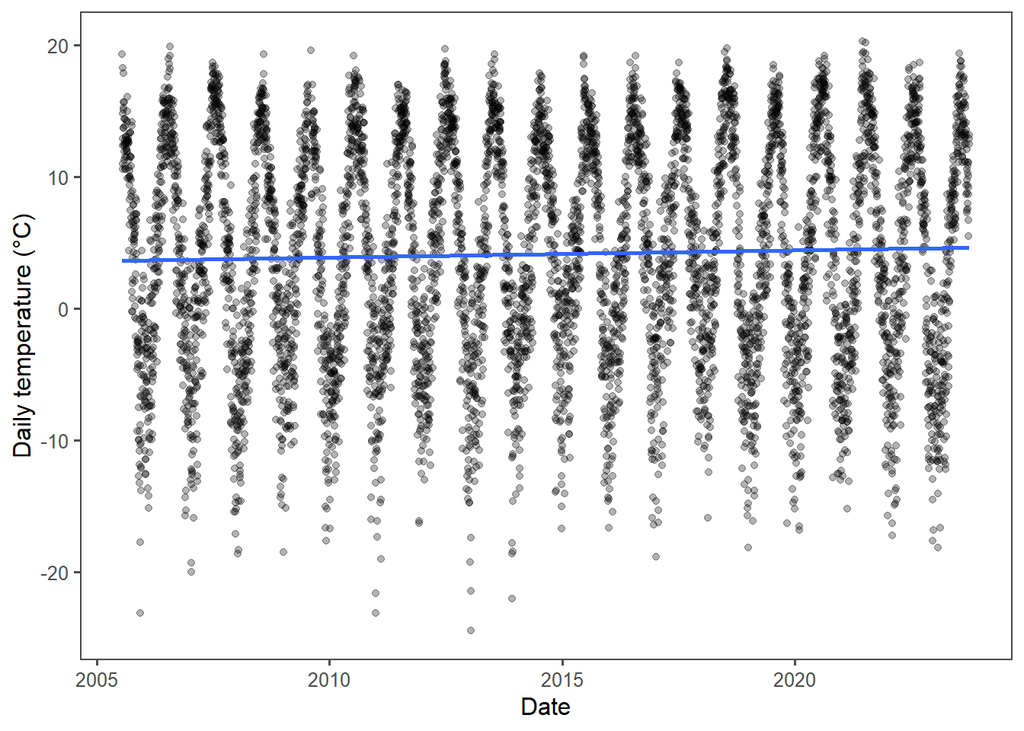

```r
# Check for outliers

ggplot(snotel_4_2_6_clean, aes(x = Date, y = temperature_mean)) +
  geom_point(alpha =0.3) + #lwd = 2) +
  theme_few() +
  geom_smooth(method = "lm", se=FALSE) +
  ylab('Daily temperature (°C)') +
  xlab('Date')
```

```r
# # For SF average annual temp
# sf <- snotel_4_2_6_clean %>%
#   group_by(waterYear) %>%
#   mutate(anntemp = mean(temperature_mean)) %>%
#   distinct(anntemp)
#
# ggplot(sf, aes(x=waterYear, y= anntemp))+
#   geom_point()+
#   geom_smooth(method = "lm", se=TRUE)+
#   theme_few()
```

**Raw SNOTEL 426 average temperatures for water years 2006-2023**

```r
snotel_4_2_6_clean <- snotel_4_2_6_clean %>%
  mutate(temp_diff = abs(temperature_min - temperature_max)) %>%
  filter(temperature_mean > -50) %>%
  filter(temp_diff < 40)
```

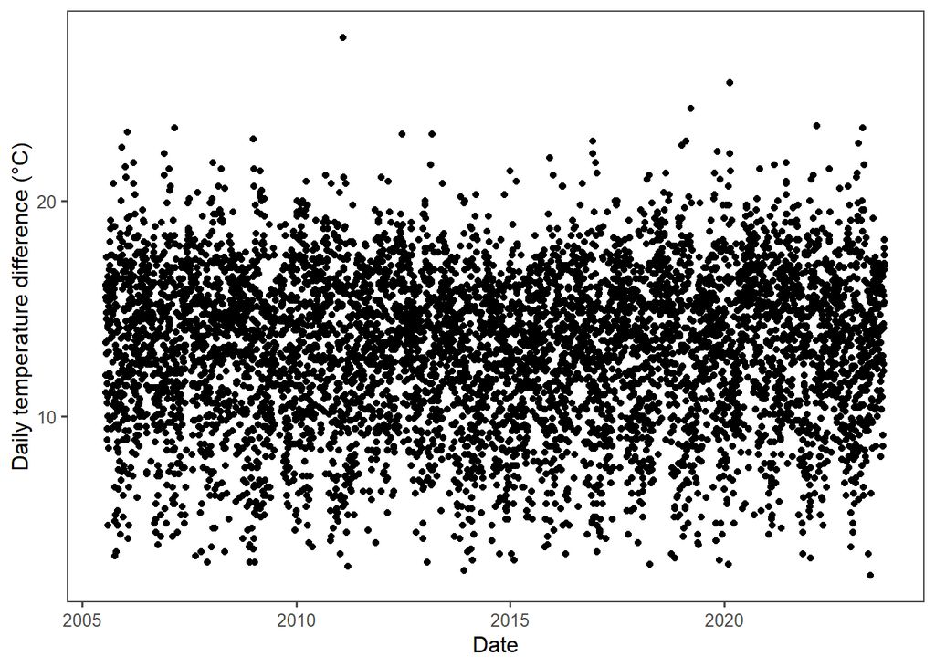

```r
ggplot(snotel_4_2_6_clean, aes(x = Date, y = temp_diff)) +
  geom_point() + #lwd = 2) +
  theme_few() +
  #geom_smooth(method = "lm", se=FALSE) +
  ylab('Daily temperature difference (°C)') +
  xlab('Date')
```

**Maximum minus minimum SNOTEL 426 temperatures for water years 2006-2023**

```r
# filtering for too few observations in a year
snotel_4_2_6_cull_count_days <- snotel_4_2_6_clean %>%
  group_by(waterYear) %>%
  count(waterYear) %>%
  filter(n < 350)

snotel_4_2_6_cull_count_days
```

```
## # A tibble: 2 × 2
## # Groups:   waterYear [2]
##   waterYear     n
##       <dbl> <int>
## 1      2005    72
## 2      2009   340
```

```r
snotel_4_2_6_clean_culled <- snotel_4_2_6_clean %>%
  filter(waterYear != "2005" & waterYear != "2009")

# ggplot(snotel_4_2_6_clean_culled, aes(x = Date, y = temp_diff)) +
#   geom_point() + #lwd = 2) +
#   theme_few() +
#   ylab('Daily temperature varience (°C)') +
#   xlab('Date')
```

```r
# ggplot(snotel_4_2_6_clean_culled, aes(x = Date, y = temperature_mean)) +
#   geom_point() + #lwd = 2) +
#   theme_few() +
#   geom_smooth(method = "lm", se=FALSE) +
#   ylab('Daily temperature (°C)') +
#   xlab('Date')


temp_4_2_6_xts <- xts(snotel_4_2_6_clean_culled$temperature_mean, order.by = snotel_4_2_6_clean_culled$Date)

dygraph(temp_4_2_6_xts) %>%
  dyAxis("y", label = "Daily mean temperature (°C)")
```

[interactive chart not shown]

**Cleaned SNOTEL 426 average temperatures for water years 2006-2023**

Looking at minimum and maximum values

```r
# filtering for too few observations in a year
min_temp_4_2_6_xts <- xts(snotel_4_2_6_clean_culled$temperature_min, order.by = snotel_4_2_6_clean_culled$Date)

dygraph(min_temp_4_2_6_xts) %>%
  dyAxis("y", label = "Daily min temperature (°C)")
```

[interactive chart not shown]

**SNOTEL 426 minimum temperatures for water years 2006-2023**

```r
max_temp_4_2_6_xts <- xts(snotel_4_2_6_clean_culled$temperature_max, order.by = snotel_4_2_6_clean_culled$Date)


dygraph(max_temp_4_2_6_xts) %>%
  dyAxis("y", label = "Daily max temperature (°C)")
```

[interactive chart not shown]

```r
snotel_4_2_6_clean_culled <- snotel_4_2_6_clean_culled %>%
  mutate(temp_difference = (temperature_max-temperature_min))# %>%
  #filter(temperature_mean > -50) %>%
  #filter(temp_diff < 40)
```

**SNOTEL 426 maximum temperatures for water years 2006-2023**

```r
difference_temp_4_2_6_xts <- xts(snotel_4_2_6_clean_culled$temp_difference, order.by = snotel_4_2_6_clean_culled$Date)

dygraph(difference_temp_4_2_6_xts) %>%
  dyAxis("y", label = "Temperature difference (max-min) (°C)")
```

[interactive chart not shown]

**SNOTEL 426 temperature difference (max-min) for water years 2006-2023**

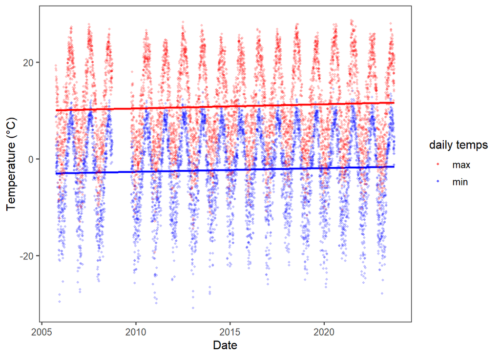

```r
# ggplot(snotel_4_2_6_clean_culled, aes(x = Date)) +
#   geom_point(aes(y = temperature_min, color = "min"), size =0.7, alpha =0.2)+
#   geom_point(aes(y = temperature_max, color = "max"), size =0.7, alpha =0.2)+
#   geom_vline(xintercept = specific_date, linetype=4, size=0.7)+
#   theme_few() +
#   geom_smooth(aes(x=Date, y = temperature_min, color = "min"), method=lm, se=FALSE)+
#   geom_smooth(aes(x=Date, y = temperature_max, color = "max"), method=lm, se=FALSE)+
#   scale_colour_manual(name = "daily temps", values=c("min"="blue", "max" = "red"))+
#     ylab('Temperature (°C)') +
#   xlab('Date')

#Basic:
# ggplot(snotel_4_2_6_clean_culled, aes(x = Date)) +
#   geom_point(aes(y = temperature_min, color = "min"), size =0.7, alpha =0.2)+
#   geom_point(aes(y = temperature_max, color = "max"), size =0.7, alpha =0.2)+
#   geom_vline(xintercept = specific_date, linetype=4, size=0.7)+
#   theme_few() +
#   geom_smooth(aes(x=Date, y = temperature_min, color = "min"), method=lm, se=FALSE)+
#   geom_smooth(aes(x=Date, y = temperature_max, color = "max"), method=lm, se=FALSE)+
#   scale_colour_manual(name = "daily temps", values=c("min"="blue", "max" = "red"))+
#     ylab('Temperature (°C)') +
#   xlab('Date')


before_subset <- filter(snotel_4_2_6_clean_culled, Date <"2005-07-21")
after_subset  <- filter(snotel_4_2_6_clean_culled, Date >= "2005-07-21")

ggplot() +
  geom_point(data = before_subset, aes(x = Date, y = temperature_min, color = "min"), size =0.7, alpha =0.2) +
  geom_smooth(data = before_subset, aes(x = Date, y = temperature_min), method = "lm", se = FALSE, color = "blue") +
  # Plot the second subset with another trendline
  geom_point(data = after_subset, aes(x = Date, y = temperature_min, color = "min"), size =0.7, alpha =0.2) +
  geom_smooth(data = after_subset, aes(x = Date, y = temperature_min), method = "lm", se = FALSE, color = "blue")+
  geom_point(data = before_subset, aes(x = Date, y = temperature_max, color = "max"), size =0.7, alpha =0.2) +
  geom_smooth(data = before_subset, aes(x = Date, y = temperature_max), method = "lm", se = FALSE, color = "red") +
  # Plot the second subset with another trendline
  geom_point(data = after_subset, aes(x = Date, y = temperature_max, color = "max"), size =0.7, alpha =0.2) +
  geom_smooth(data = after_subset, aes(x = Date, y = temperature_max), method = "lm", se = FALSE, color = "red")+
  #geom_vline(xintercept = specific_date, linetype=4, size=0.7)+
  theme_few() +
  scale_colour_manual(name = "daily temps", values=c("min"="blue", "max" = "red"))+
  ylab('Temperature (°C)') +
  xlab('Date')
```

**Daily SNOTEL 426 minimum and maximum temperatures for water years 2006-2023**

Crosho 426

Need two datasets:

1. NRCS pre-sensor change data (not adjusted) *“temperature_mean”*
2. NRCS post-sensor change adjusted data (NOAA9/CONUS) *“noaa_conus”*

```r
# 2) NRCS pre-sensor change adjusted data (Morrisey) *"morrisey"*

snotel_4_2_6_adjusted <- snotel_4_2_6_clean_culled %>%
  # mutate(morrisey = if_else(Date < "2005-07-21", ((5.3*10^(-7))*(temperature_mean^(4))+(3.72*10^(-5))*(temperature_mean^(3))-(2.16*10^(-3))*(temperature_mean^(2))-(7.32*10^(-2))*(temperature_mean)+1.37)+temperature_mean, temperature_mean)) %>%
   mutate(noaa_conus = if_else(Date >= "2005-07-21", 610558.226380138*(((temperature_mean+65.929))/194.45)^9-2056177.65461394*(((temperature_mean+65.929))/194.45)^8+2937046.42906361*(((temperature_mean+65.929))/194.45)^7-2319657.12916417*(((temperature_mean+65.929))/194.45)^6+1111854.33825836*(((temperature_mean+65.929))/194.45)^5-337069.883250001*(((temperature_mean+65.929))/194.45)^4+66105.7015922199*(((temperature_mean+65.929))/194.45)^3- 8386.78320604513*(((temperature_mean+65.929))/194.45)^2+ 824.818021779729*(((temperature_mean+65.929))/194.45)-86.7321006757439, temperature_mean)) #%>%
  # mutate(noaa_morrisey = 610558.226380138*(((morrisey+65.929))/194.45)^9-2056177.65461394*(((morrisey+65.929))/194.45)^8+2937046.42906361*(((morrisey+65.929))/194.45)^7-2319657.12916417*(((morrisey+65.929))/194.45)^6+1111854.33825836*(((morrisey+65.929))/194.45)^5-337069.883250001*(((morrisey+65.929))/194.45)^4+66105.7015922199*(((morrisey+65.929))/194.45)^3- 8386.78320604513*(((morrisey+65.929))/194.45)^2+ 824.818021779729*(((morrisey+65.929))/194.45)-86.7321006757439)

#Adding min-max

snotel_4_2_6_adjusted <- snotel_4_2_6_adjusted %>%
#  mutate(min_morrisey = if_else(Date < "2005-07-21", ((5.3*10^(-7))*(temperature_min^(4))+(3.72*10^(-5))*(temperature_min^(3))-(2.16*10^(-3))*(temperature_min^(2))-(7.32*10^(-2))*(temperature_min)+1.37)+temperature_min, temperature_min)) %>%
  mutate(noaa_conus_min = if_else(Date >= "2005-07-21", 610558.226380138*(((temperature_min+65.929))/194.45)^9-2056177.65461394*(((temperature_min+65.929))/194.45)^8+2937046.42906361*(((temperature_min+65.929))/194.45)^7-2319657.12916417*(((temperature_min+65.929))/194.45)^6+1111854.33825836*(((temperature_min+65.929))/194.45)^5-337069.883250001*(((temperature_min+65.929))/194.45)^4+66105.7015922199*(((temperature_min+65.929))/194.45)^3- 8386.78320604513*(((temperature_min+65.929))/194.45)^2+ 824.818021779729*(((temperature_min+65.929))/194.45)-86.7321006757439, temperature_min)) #%>%
#  mutate(noaa_min_morrisey = 610558.226380138*(((min_morrisey+65.929))/194.45)^9-2056177.65461394*(((min_morrisey+65.929))/194.45)^8+2937046.42906361*(((min_morrisey+65.929))/194.45)^7-2319657.12916417*(((min_morrisey+65.929))/194.45)^6+1111854.33825836*(((min_morrisey+65.929))/194.45)^5-337069.883250001*(((min_morrisey+65.929))/194.45)^4+66105.7015922199*(((min_morrisey+65.929))/194.45)^3- 8386.78320604513*(((min_morrisey+65.929))/194.45)^2+ 824.818021779729*(((min_morrisey+65.929))/194.45)-86.7321006757439)

#max

snotel_4_2_6_adjusted <- snotel_4_2_6_adjusted %>%
#  mutate(max_morrisey = if_else(Date < "2005-07-21", ((5.3*10^(-7))*(temperature_max^(4))+(3.72*10^(-5))*(temperature_max^(3))-(2.16*10^(-3))*(temperature_max^(2))-(7.32*10^(-2))*(temperature_max)+1.37)+temperature_max, temperature_max)) %>%
  mutate(noaa_conus_max = if_else(Date >= "2005-07-21", 610558.226380138*(((temperature_max+65.929))/194.45)^9-2056177.65461394*(((temperature_max+65.929))/194.45)^8+2937046.42906361*(((temperature_max+65.929))/194.45)^7-2319657.12916417*(((temperature_max+65.929))/194.45)^6+1111854.33825836*(((temperature_max+65.929))/194.45)^5-337069.883250001*(((temperature_max+65.929))/194.45)^4+66105.7015922199*(((temperature_max+65.929))/194.45)^3- 8386.78320604513*(((temperature_max+65.929))/194.45)^2+ 824.818021779729*(((temperature_max+65.929))/194.45)-86.7321006757439, temperature_max)) #%>%
#  mutate(noaa_max_morrisey = 610558.226380138*(((max_morrisey+65.929))/194.45)^9-2056177.65461394*(((max_morrisey+65.929))/194.45)^8+2937046.42906361*(((max_morrisey+65.929))/194.45)^7-2319657.12916417*(((max_morrisey+65.929))/194.45)^6+1111854.33825836*(((max_morrisey+65.929))/194.45)^5-337069.883250001*(((max_morrisey+65.929))/194.45)^4+66105.7015922199*(((max_morrisey+65.929))/194.45)^3- 8386.78320604513*(((max_morrisey+65.929))/194.45)^2+ 824.818021779729*(((max_morrisey+65.929))/194.45)-86.7321006757439)
```

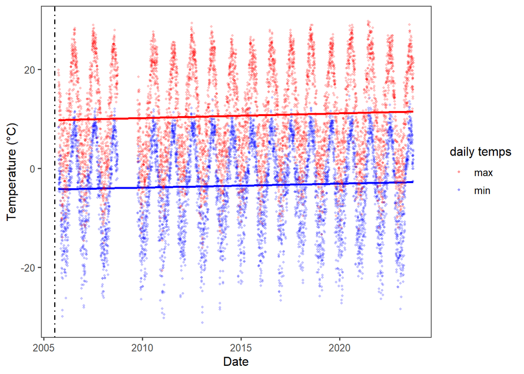

```r
# ggplot(snotel_4_2_6_adjusted, aes(x = Date)) +
#   geom_point(aes(y = temperature_min, color = "min"), size =0.7, alpha =0.2)+
#   geom_point(aes(y = temperature_max, color = "max"), size =0.7, alpha =0.2)+
#   geom_vline(xintercept = specific_date, linetype=4, size=0.7)+
#   theme_few() +
#   geom_smooth(aes(x=Date, y = temperature_min, color = "min"), method=lm, se=FALSE)+
#   geom_smooth(aes(x=Date, y = temperature_max, color = "max"), method=lm, se=FALSE)+
#   scale_colour_manual(name = "daily temps", values=c("min"="blue", "max" = "red"))+
#     ylab('Temperature (°C)') +
#   xlab('Date')

adj_before_subset <- filter(snotel_4_2_6_adjusted, Date <"2005-07-21")
adj_after_subset  <- filter(snotel_4_2_6_adjusted, Date >= "2005-07-21")

ggplot() +
  # geom_point(data = adj_before_subset, aes(x = Date, y = noaa_min_morrisey, color = "min"), size =0.7, alpha =0.2) +
  # geom_smooth(data = adj_before_subset, aes(x = Date, y = noaa_min_morrisey), method = "lm", se = FALSE, color = "blue") +
  # Plot the second subset with another trendline
  geom_point(data = adj_after_subset, aes(x = Date, y = noaa_conus_min, color = "min"), size =0.7, alpha =0.2) +
  geom_smooth(data = adj_after_subset, aes(x = Date, y = noaa_conus_min), method = "lm", se = FALSE, color = "blue")+
  # geom_point(data = adj_before_subset, aes(x = Date, y = noaa_max_morrisey, color = "max"), size =0.7, alpha =0.2) +
  # geom_smooth(data = adj_before_subset, aes(x = Date, y = noaa_max_morrisey), method = "lm", se = FALSE, color = "red") +
  # Plot the second subset with another trendline
  geom_point(data = adj_after_subset, aes(x = Date, y = noaa_conus_max, color = "max"), size =0.7, alpha =0.2) +
  geom_smooth(data = adj_after_subset, aes(x = Date, y = noaa_conus_max), method = "lm", se = FALSE, color = "red")+
  geom_vline(xintercept = specific_date, linetype=4, size=0.7)+
  theme_few() +
  scale_colour_manual(name = "daily temps", values=c("min"="blue", "max" = "red"))+
  ylab('Temperature (°C)') +
  xlab('Date')
```

**NOAA9 corrected SNOTEL 426 minimum and maximum temperatures for water years 2006-2023**

4_2_6 temperature_mean mean SD and median SD NON-CORRECTED.

```r
#average water year temperature
yearly_wy_aver_4_2_6 <- snotel_4_2_6_adjusted %>%
  group_by(waterYear) %>%
  mutate(aver_ann_temp = mean(temperature_mean))
#Average temperature by day for all water years:
daily_wy_aver_4_2_6 <- yearly_wy_aver_4_2_6 %>%
  group_by(daymonth) %>%
  mutate(aver_day_temp = mean(temperature_mean))
#average mean temperature by day for the period of record:
daily_wy_aver_4_2_6 <- daily_wy_aver_4_2_6 %>%
  group_by(daymonth) %>%
  mutate(all_ave_temp = mean(daily_wy_aver_4_2_6$aver_day_temp))
# try to show all years as means.
daily_wy_aver2_4_2_6 <-daily_wy_aver_4_2_6 %>%
  group_by(waterDay) %>%
  mutate(date_temp = mean(temperature_mean))

daily_wy_aver2_4_2_6$date_temp <- (daily_wy_aver2_4_2_6$date_temp) #reduce the sig figs
# ggplot(daily_wy_aver2_4_2_6, aes(x = waterDay, y = date_temp))+
#   geom_line(size= 0.7) +
#   theme_few() +
#   ylab('Average Daily temperature (°C)') +
#   xlab('Day of water year')

# mean SD

standard_dev_4_2_6 <- daily_wy_aver_4_2_6 %>%
  group_by(waterYear) %>%
  mutate(residual = (all_ave_temp-aver_ann_temp)+temperature_mean-aver_day_temp) %>%
  mutate(deviation = abs(residual-lag(residual)))
standard_dev_all_4_2_6 <- standard_dev_4_2_6 %>%
  group_by(waterYear) %>%
  mutate(nmbr = n())
standard_dev_all_4_2_6 <- standard_dev_all_4_2_6 %>%
  group_by(waterYear) %>%
  mutate(resid_mean = mean(residual)) %>%
  mutate(sd_1 = residual-resid_mean) %>%
  mutate(sd_2 = (((sum((sd_1)^2))/((nmbr-1))))^(0.5)) %>%
  distinct(sd_2, .keep_all = TRUE) %>%
   select(waterYear, sd_2)
standard_dev_all_4_2_6 %>%
  kable(.,'html') %>%
  kable_styling() %>%
  scroll_box(width='250px',height='500px')
```

| waterYear | sd_2 |
| --- | --- |
| 2006 | 4.001221 |
| 2007 | 3.993026 |
| 2008 | 3.895972 |
| 2010 | 3.659666 |
| 2011 | 3.703503 |
| 2012 | 3.688673 |
| 2013 | 3.923955 |
| 2014 | 3.945003 |
| 2015 | 3.792631 |
| 2016 | 3.523974 |
| 2017 | 4.381545 |
| 2018 | 3.669559 |
| 2019 | 3.690620 |
| 2020 | 4.008933 |
| 2021 | 3.732675 |
| 2022 | 3.879252 |
| 2023 | 4.009951 |

```r
# adding median SD
standard_dev_all_4_2_6_med <- standard_dev_4_2_6 %>%
  group_by(waterYear) %>%
  mutate(nmbr = n())
standard_dev_all_4_2_6_med <- standard_dev_all_4_2_6_med %>%
  group_by(waterYear) %>%
  mutate(resid_median = median(residual)) %>%
  mutate(sd_1_med = residual-resid_median) %>%
  mutate(sd_2_med = (((sum((sd_1_med)^2))/((nmbr-1))))^(0.5)) %>%
  distinct(sd_2_med, .keep_all = TRUE) %>%
   select(waterYear, sd_2_med)
standard_dev_all_4_2_6_med %>%
  kable(.,'html') %>%
  kable_styling() %>%
  scroll_box(width='250px',height='500px')
```

| waterYear | sd_2_med |
| --- | --- |
| 2006 | 4.001854 |
| 2007 | 4.051833 |
| 2008 | 3.913051 |
| 2010 | 3.668524 |
| 2011 | 3.703540 |
| 2012 | 3.689049 |
| 2013 | 3.994155 |
| 2014 | 3.945534 |
| 2015 | 3.793385 |
| 2016 | 3.524330 |
| 2017 | 4.383182 |
| 2018 | 3.669677 |
| 2019 | 3.720426 |
| 2020 | 4.072453 |
| 2021 | 3.760787 |
| 2022 | 3.879554 |
| 2023 | 4.018489 |

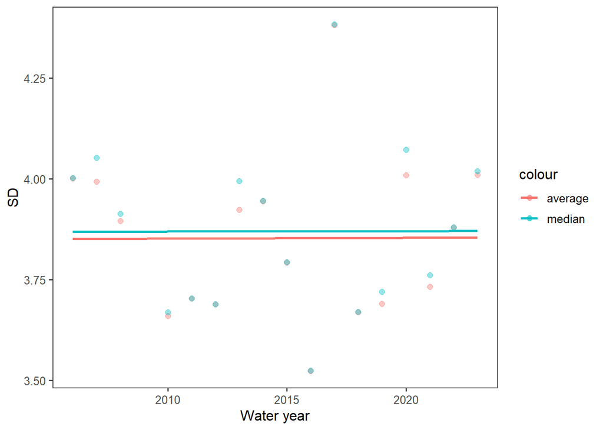

```r
standard_dev_all_4_2_6 <- standard_dev_all_4_2_6 %>%
  left_join(standard_dev_all_4_2_6_med, by= 'waterYear')

ggplot(standard_dev_all_4_2_6, aes(x = waterYear))+
  geom_point(aes(y = sd_2, color = 'average'), size =2, alpha =0.4)+
  geom_smooth(aes(y = sd_2, color = 'average'), method = lm, se= FALSE)+
  geom_point(aes(y = sd_2_med, color = 'median'), size =2, alpha =0.4)+
  geom_smooth(aes(y = sd_2_med, color = 'median'), method = lm, se= FALSE)+
  theme_few() +
  #geom_smooth(method = "lm", se=FALSE) +
  ylab('SD') +
  xlab('Water year')
```

**Mean and median standard deviation of SNOTEL 426 average temperatures for water years 2006-2023**

```r
#using the clean culled df:
#average water year temperature
yearly_wy_aver_4_2_6_noaa_conus <- snotel_4_2_6_adjusted %>%
  group_by(waterYear) %>%
  mutate(aver_ann_temp_noaa_conus = mean(noaa_conus))
#Average temperature by day for all water years:
daily_wy_aver_4_2_6_noaa_conus <- yearly_wy_aver_4_2_6_noaa_conus %>%
  group_by(daymonth) %>%
  mutate(aver_day_temp_noaa_conus = mean(noaa_conus))
#average mean temperature by day for the period of record:
daily_wy_aver_4_2_6_noaa_conus <- daily_wy_aver_4_2_6_noaa_conus %>%
  group_by(daymonth) %>%
  mutate(all_ave_temp_noaa_conus = mean(daily_wy_aver_4_2_6_noaa_conus$aver_day_temp_noaa_conus))
# try to show all years as means.
daily_wy_aver2_4_2_6_noaa_conus <-daily_wy_aver_4_2_6_noaa_conus %>%
  group_by(waterDay) %>%
  mutate(date_temp_noaa_conus = mean(noaa_conus))

daily_wy_aver2_4_2_6_noaa_conus$date_temp_noaa_conus <- signif(daily_wy_aver2_4_2_6_noaa_conus$date_temp_noaa_conus,3) #reduce the sig figs
# ggplot(daily_wy_aver2_4_2_6_noaa_conus, aes(x = waterDay, y = date_temp_noaa_conus))+
#   geom_line(size= 0.7) +
#   theme_few() +
#   ylab('Average Daily temperature (°C)') +
#   xlab('Day of water year')

standard_dev_4_2_6_noaa_conus <- daily_wy_aver_4_2_6_noaa_conus %>%
  group_by(waterYear) %>%
  #filter(waterYear >= 1987 & waterYear <= 2021) %>%
  mutate(residual = (all_ave_temp_noaa_conus-aver_ann_temp_noaa_conus)+noaa_conus-aver_day_temp_noaa_conus) %>%
  mutate(deviation = abs(residual-lag(residual)))
standard_dev_all_4_2_6_noaa_conus <- standard_dev_4_2_6_noaa_conus %>%
  group_by(waterYear) %>%
  mutate(nmbr = n())
standard_dev_all_4_2_6_noaa_conus <- standard_dev_all_4_2_6_noaa_conus %>%
  group_by(waterYear) %>%
  mutate(resid_mean = mean(residual)) %>%
  mutate(sd_1 = residual-resid_mean) %>%
  mutate(sd_2 = (((sum((sd_1)^2))/((nmbr-1))))^(0.5)) %>%
  distinct(sd_2, .keep_all = TRUE) %>%
   select(waterYear, sd_2)
standard_dev_all_4_2_6_noaa_conus %>%
  kable(.,'html') %>%
  kable_styling() %>%
  scroll_box(width='250px',height='500px')
```

| waterYear | sd_2 |
| --- | --- |
| 2006 | 4.248725 |
| 2007 | 4.228187 |
| 2008 | 4.138303 |
| 2010 | 3.899863 |
| 2011 | 3.897956 |
| 2012 | 3.958485 |
| 2013 | 4.122744 |
| 2014 | 4.184658 |
| 2015 | 4.047951 |
| 2016 | 3.758410 |
| 2017 | 4.679990 |
| 2018 | 3.940342 |
| 2019 | 3.932882 |
| 2020 | 4.272239 |
| 2021 | 4.004618 |
| 2022 | 4.120433 |
| 2023 | 4.229410 |

```r
# ggplot(standard_dev_all_4_2_6_noaa_conus, aes(x = waterYear, y = sd_2))+
#   geom_line(size= 0.7) +
#   theme_few() +
#   geom_smooth(method = "lm", se=FALSE) +
#   ylab('SD') +
#   xlab('Water year')

# adding median SD
standard_dev_all_4_2_6_med_noaa_conus <- standard_dev_4_2_6_noaa_conus %>%
  group_by(waterYear) %>%
  mutate(nmbr = n())
standard_dev_all_4_2_6_med_noaa_conus <- standard_dev_all_4_2_6_med_noaa_conus %>%
  group_by(waterYear) %>%
  mutate(resid_median = median(residual)) %>%
  mutate(sd_1_med = residual-resid_median) %>%
  mutate(sd_2_med = (((sum((sd_1_med)^2))/((nmbr-1))))^(0.5)) %>%
  distinct(sd_2_med, .keep_all = TRUE) %>%
   select(waterYear, sd_2_med)
standard_dev_all_4_2_6_med_noaa_conus %>%
  kable(.,'html') %>%
  kable_styling() %>%
  scroll_box(width='250px',height='500px')
```

| waterYear | sd_2_med |
| --- | --- |
| 2006 | 4.248850 |
| 2007 | 4.287791 |
| 2008 | 4.152121 |
| 2010 | 3.905204 |
| 2011 | 3.898003 |
| 2012 | 3.959127 |
| 2013 | 4.194744 |
| 2014 | 4.185366 |
| 2015 | 4.048792 |
| 2016 | 3.758882 |
| 2017 | 4.681218 |
| 2018 | 3.940361 |
| 2019 | 3.963761 |
| 2020 | 4.332304 |
| 2021 | 4.027434 |
| 2022 | 4.120804 |
| 2023 | 4.236792 |

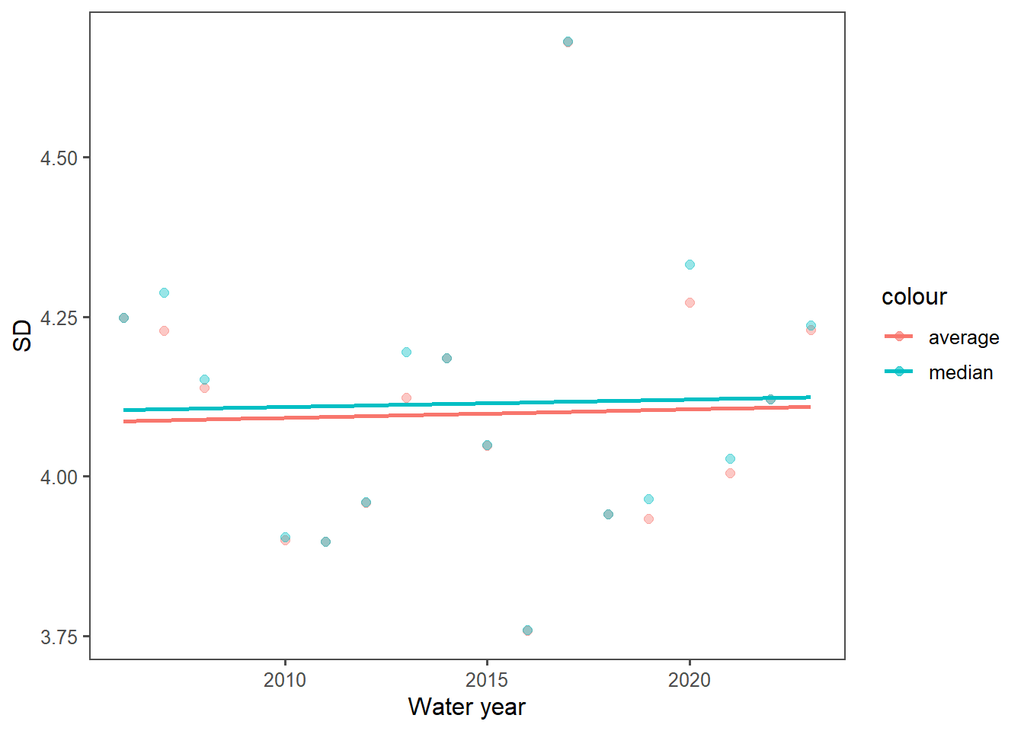

```r
standard_dev_all_4_2_6_noaa_conus <- standard_dev_all_4_2_6_noaa_conus %>%
  left_join(standard_dev_all_4_2_6_med_noaa_conus, by= 'waterYear')

standard_dev_all_4_2_6_noaa_conus <- standard_dev_all_4_2_6_noaa_conus %>%
  mutate(differ = sd_2-sd_2_med)

ggplot(standard_dev_all_4_2_6_noaa_conus, aes(x = waterYear))+
  geom_point(aes(y = sd_2, color = 'average'), size =2, alpha =0.4)+
  geom_smooth(aes(y = sd_2, color = 'average'), method = lm, se= FALSE)+
  geom_point(aes(y = sd_2_med, color = 'median'), size =2, alpha =0.4)+
  geom_smooth(aes(y = sd_2_med, color = 'median'), method = lm, se= FALSE)+
  theme_few() +
  #geom_smooth(method = "lm", se=FALSE) +
  ylab('SD') +
  xlab('Water year')
```

**NOAA9 corrected mean and median standard deviation of SNOTEL 426 average temperatures for water years 2006-2023**